[figure not shown]

# Uncovering the epigenetic landscape: *Methylator*, a comprehensive framework for analyzing DNA methylation across species, library preparations, with application to plant adaptation

### Eylül Harputluoglu†<sup>1,2</sup>, Jonas Bucher†<sup>1,2</sup>, Masaomi Hatakeyama<sup>3,4</sup>, Jürgen Bernard<sup>5</sup>, Ueli Grossniklaus<sup>1,2**</sup>, Deepak K. Tanwar<sup>1,2**</sup>

##### <sup>1</sup> URPP Evolution in Action, University of Zurich; <sup>2</sup> Plant Development Genetics, Department of Plant and Microbial Biology, University of Zurich; <sup>3</sup> Evolutionary and Ecological Genomics, Department of Evolutionary Biology and Environmental Studies, University of Zurich; <sup>4</sup> Functional Genomics Center Zurich, ETH Zurich and University of Zurich; <sup>5</sup> Department of Computer Science, University of Zurich ** grossnik@botinst.uzh.ch | deepak.tanwar@evolution.uzh.ch

# Introduction

DNA cytosine methylation is the addition of a methyl group to a cytosine in the DNA. It impacts transcription and therefore plays a major role in several vital processes. In mammals, DNA cytosine methylation predominantly occurs in CG sequence contexts. In plants, in addition to the CG context, the CHG and CHH contexts are common as well.

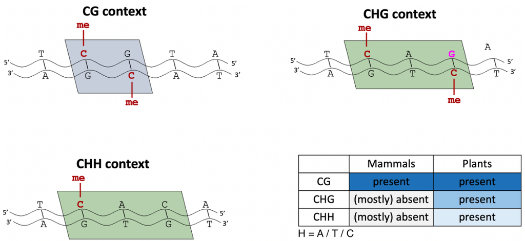

**Figure 1:** Methylation contexts in mammals and plants.

# Aims of the project

# Methylator

## Data analysis framework

Here we introduce `Methylator`, a user-friendly tool for a full DNA cytosine methylation analysis, with an easy-to-use interface, facilitated reproducibility and interactive visualizations of results.

[figure not shown]

**Figure 2:** Overview of `Methylator`

## Dirty-Harry for aligment of methylation data

Bisulfite treatment of DNA results in a decreased sequence quality, which deteriorates mapping efficiency. Overall, this causes loss of a big proportion of the sequencing data for analysis. The Dirty Harry method offers an improvement to the mapping rate by remapping the unaligned reads locally. Through that, this method increases the mapping efficiency and retains a considerable amount of cytosine sites, which would otherwise be lost.

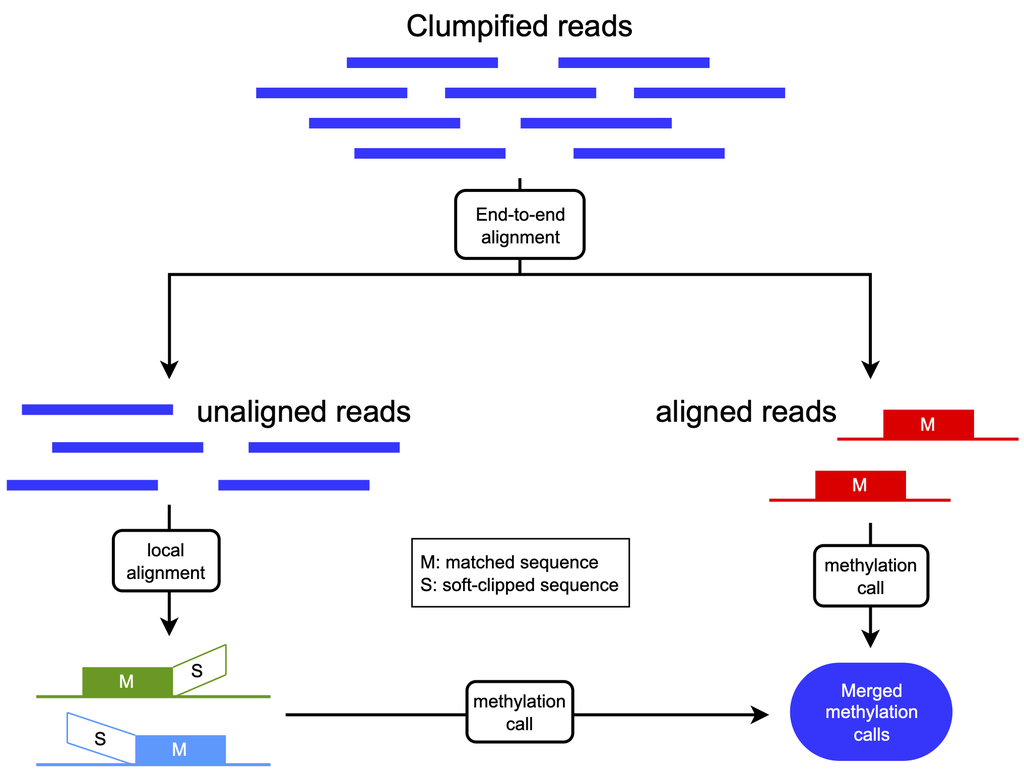

**Figure 3:** Dirty Harry alignment method. Adapted from (Wu et al. 2019)

# Methylator’s application

## Datasets

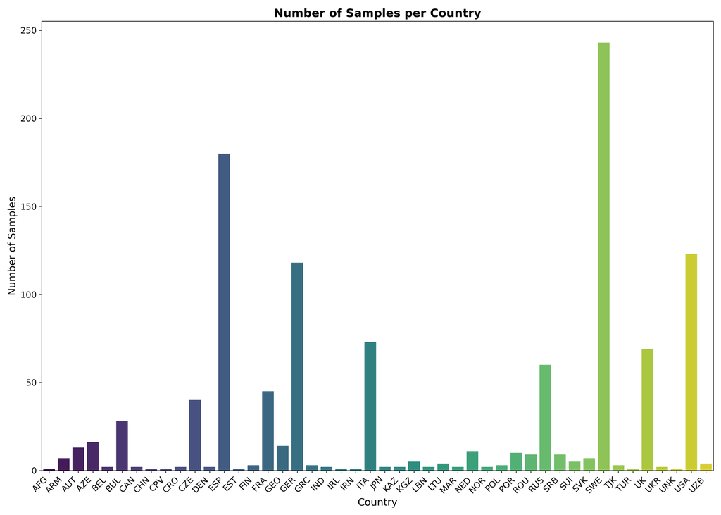

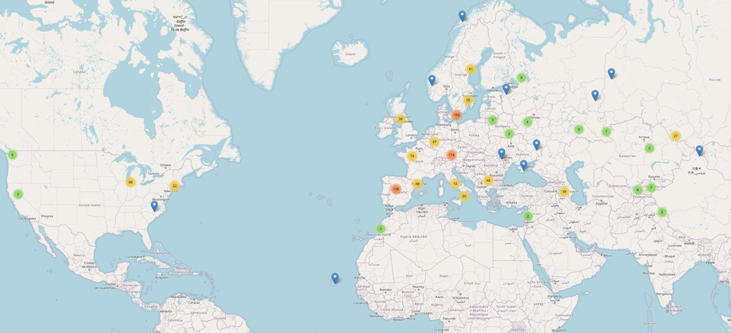

**Figure 4:** Dataset distribution (top-left) and sample count per country for the 1001 Arabidopsis Epigenomes Project

## Jensen-Shannon Divergence calculation

Jensen-Shannon Divergence (JSD) measures the similarity between probability distributions, providing a symmetric comparison of datasets. In DNA methylation analysis, JSD can be used to compare methylation patterns across samples, identifying regions with significant epigenetic differences (Kartal, Schmid, and Grossniklaus 2020).

$$D(\{P_j\}) = H\left(\sum_j \pi_j P_j\right) - \sum_j \pi_j H(P_j)$$

$$H(P_j) = -\sum_k P_{jk} \log_b P_{jk}$$

# Results

## Comparison of `Methylator` with existing tools

Methylator

methylseq

ARPEGGIO

MethylStar

MethylC-analyzer

Bycicle

Platform independent

### ✓

### ✓

### ✕

### ✓

### ✕

### ✓

Self-contained

### ✓

### ✓

### ✓

### ✓

### ✕

### ✓

Interface

GUI (SUSHI, Galaxy, Shiny), CLI

CLI

CLI

CLI

CLI, GUI

CLI

Input Data

WGBS, RRBS, PBAT, TAPS, ABBS, single-cell

WGBS, RRBS

WGBS

WGBS, PBAT

WGBS, RRBS

Targeted BS

Single-cell

### ✓

### ✕

### ✕

### ✓

### ✕

### ✕

Bulk

### ✓

### ✕

### ✕

### ✓

### ✕

### ✕

Supported genomes

Mammals, Plants (incl. Polyploids)

General

Polyploids

Mammals, Plants

Mammals, Plants

General

Quality control

### ✓

### ✓

### ✓

### ✓

### ✕

### ✓

Alignment

Bismark, Arioc (GPU-based), EAGLE-RC

Bismark, bwa-meth

Bismark, EAGLE-RC

Bismark

### ✕

Bowtie (Custom)

Deduplication

Clumpify

Bismark, Picard

Bismark

Bismark

### ✕

Custom

Exploratory data analysis

PCA, heatmaps, methylation summaries

### ✕

### ✕

### ✕

PCA, heatmaps, methylation summaries

### ✕

Differential methylation analysis

DMRs, DMLs

### ✕

### ✓

### ✕

DMRs and DMGs

### ✓

Copy number variation analysis

CNVkit

### ✕

### ✕

### ✕

### ✕

### ✕

Functional analysis

GO, Kegg, Reactome, user-defined

### ✕

### ✕

### ✕

### ✕

### ✕

Motif analysis

Homer

### ✕

### ✕

### ✕

### ✕

### ✕

Visualization

### ✓

### ✕

### ✕

### ✕

### ✓

### ✕

Year published

In development

2020

2021

2020

2023

2018

**Table 1:** Comparison with features of widely used tools.

GUI = graphical user interface, CLI = command line interface  
DMR/DML/DMG = Differentially Methylated Regions/Loci/Genes  
GO = Gene Ontology

## Temperature effect on DNA Methylation

We analyzed the impact of different temperature conditions (10°C, 16°C, 22°C) on DNA methylation in the CHG, CHH, and CpG contexts across various genomic regions. By calculating the JSD and methylation levels, we revealed distinct patterns of methylation context-specific changes across these temperature conditions.

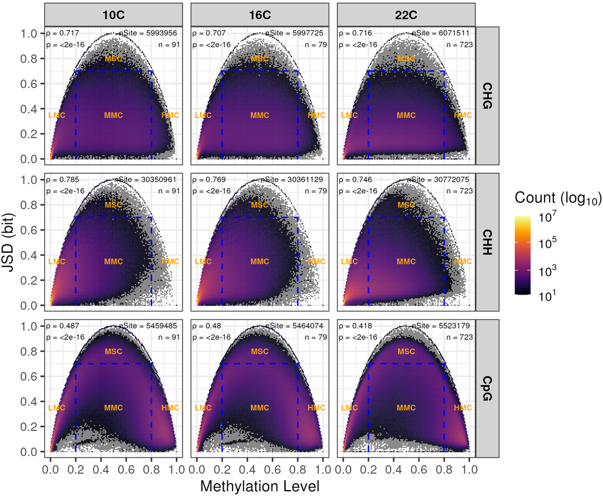

**Figure 5:** Jensen-Shannon Divergence (JSD) as a function of methylation levels in CHG, CHH, and CpG contexts under three temperature conditions.

We further explored how methylation levels and JSD vary across different genomic regions, such as exonic, intergenic, and transposable elements, under three temperature conditions (10°C, 16°C, 22°C). This analysis aimed to identify regions that are particularly sensitive to temperature-induced epigenetic changes. The results could provide a clearer image of how genomic context influences methylation patterns and gene regulation in response to environmental stress.

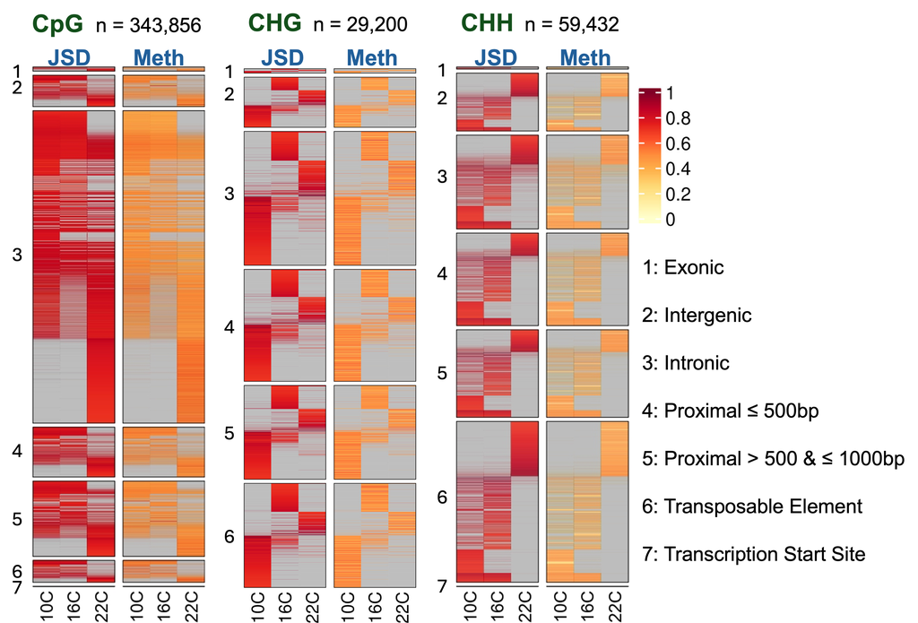

**Figure 6:** Heatmap comparison of methylation levels (Meth) and JSD across various genomic regions (exonic, intergenic, intronic, etc.) and temperatures (10°C, 16°C, 22°C) in CHG, CHH, and CpG contexts.

# Conclusion

**`Methylator`**: A versatile and sustainable framework for DNA cytosine methylation analysis, supporting plants and mammals, compatible with diverse library preparation methods, and offering interactive result visualizations.

Our findings highlight the role of temperature in shaping DNA methylation patterns across genomic regions, offering insights into context-specific epigenetic responses to environmental stress.

# Funding

- URPP Evolution in Action, University of Zurich
- Faculty of Science, University of Zurich

# Code

**GitHub:** github.com/urppeia

# References

Kartal, Önder, Marc W. Schmid, and Ueli Grossniklaus. 2020. “Cell Type-Specific Genome Scans of DNA Methylation Divergence Indicate an Important Role for Transposable Elements.” *Genome Biology* 21 (1). https://doi.org/10.1186/s13059-020-02068-2.

Wu, Peng, Yan Gao, Weilong Guo, and Ping Zhu. 2019. “Using Local Alignment to Enhance Single-Cell Bisulfite Sequencing Data Efficiency.” Edited by Inanc Birol. *Bioinformatics* 35 (18): 3273–78. https://doi.org/10.1093/bioinformatics/btz125.